# A Simple Regression Function

Andre-Ignace Ghonda Lukoki

March 20th, 2024

### Introduction

For this project, I attempt to create a function for a simple regression function with one dependent and one independent variable.

### The sample

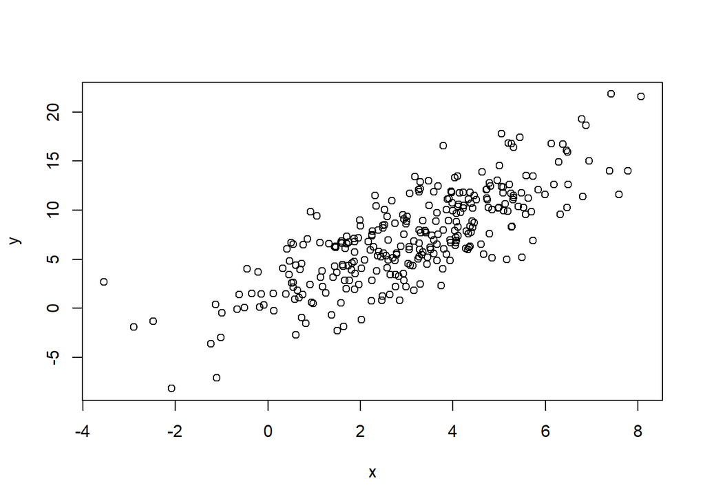

```r
set.seed(2024)

# Sample Creation

x <- rnorm(n = 300, mean = 3, sd = 2)

y <- 2*x + rnorm(n = 300, mean = 1, sd = 3)

# Plot

plot(x, y)
```

### The function

A simple regression model is an equation of the following form:

$$\tag{1} Y_{i} = \alpha + \beta x_{i} \quad i = 1, \dots, n$$

This function takes two arguments. The first one is the dependent variable, usually denoted by $Y_{i}$, and the second argument is the independent variable $x_{i}$. The coefficient on the independent variable is the average effect of $x_{i}$ on $Y_{i}$ in the population. The coefficient $\alpha$ is simply the intercept of our model. To estimate both of those parameters, I will use *Ordinary Least Squares* to get the best linear predictor for $\mathbb{E}[Y|X]$.

The intercept $\alpha$ is given by the following formula:

$$\tag{2} \alpha = \bar{y} - \beta \bar{x}$$

$\rightarrow$ Note that $\overline{a}$ simply denotes the mean of the random variable $a_{i}$.

The $\beta$ coefficient is given by the covariance between the two variables divided by the variable of the independent variable.

$$\tag{3} \beta = \frac {Cov(X,Y)}{Var(X)}$$

```r
regress <- function(y, x, truebeta = 0, alpha = 0.05) {

  dataset <- data.frame(y, x)

  # Sample Size
  n <- nrow(dataset)

  # Find mean of data

  meanX <- mean(dataset[,2])
  meanY <- mean(dataset[,1])

  # Calculating Beta

  Covariance <- sum((x - meanX) * (y - meanY))
  Variance <- sum((x - meanX) ^ 2)

  # Calculating Estimators

  slope <- Covariance / Variance
  intercept <- meanY - slope * meanX

  # Calculate error term

  error <- rep(0, n)

  for (i in 1:n){

    error[i] <- dataset[i, 1] - intercept -  slope * dataset[i, 2]
  }

  # SE of Slope

  var.slope <- sum(error^2) / ((n - 2) * Variance)

  se.slope <- sqrt(var.slope)

  # T(X) of Slope

  T.slope <- (slope - truebeta) / se.slope

  # P-value of T(X)

  p.slope <- pt(T.slope, df = n - 1, lower.tail = FALSE)

  # Confidence Interval for slope

  p <- alpha / 2
  level <- 1 - alpha

    # Bounds

  Lower <- slope - qt(p, n - 1, lower.tail = FALSE) * se.slope
  Upper <- slope + qt(p, n - 1, lower.tail = FALSE) * se.slope

 # Print Output to console

  cat("Regression: \n")
  cat("Method: Ordinary Least Squares \n")
  cat("___________________________________ \n")
  cat("          ", "Estimate ", "Std Error", "\n")
  cat("Intercept:", intercept, "\n")
  cat("    Slope:", slope,      se.slope, "\n")
  cat("\n")
  cat("Hypothesis Testing: \n")
  cat("----------------------------------- \n")
  cat("Null: the slope is less or equal to", truebeta, "\n")
  cat("Alt: the slope is greater than", truebeta, "\n")
  cat("\n")
  cat("          ", "T value",    "P-value", "\n")
  cat("    Slope:",  T.slope,      p.slope,  "\n")
  cat("\n")
  cat("Confidence Interval (Two-Sided): \n")
  cat("----------------------------------- \n")
  cat("The", level, "% two-sided CI for the slope is:", "\n",  "[",Lower, ";", Upper,"] \n")

}
```

### The results

Now it is time to test our function against the standard `lm()` function in R.

```r
regress(y, x)
```

```
## Regression:
## Method: Ordinary Least Squares
## ___________________________________
##            Estimate  Std Error
## Intercept: 1.397345
##     Slope: 1.880434 0.08630065
##
## Hypothesis Testing:
## -----------------------------------
## Null: the slope is less or equal to 0
## Alt: the slope is greater than 0
##
##            T value P-value
##     Slope: 21.78934 5.40485e-64
##
## Confidence Interval (Two-Sided):
## -----------------------------------
## The 0.95 % two-sided CI for the slope is:
##  [ 1.710601 ; 2.050268 ]
```

```r
# Test and compare output with lm()

test <- lm(y~x)
summary(test)
```

```
##
## Call:
## lm(formula = y ~ x)
##
## Residuals:
##    Min     1Q Median     3Q    Max
## -6.537 -1.969 -0.159  2.074  8.028
##
## Coefficients:
##             Estimate Std. Error t value Pr(>|t|)
## (Intercept)   1.3974     0.3155    4.43 1.33e-05 ***
## x             1.8804     0.0863   21.79  < 2e-16 ***
## ---
## Signif. codes:  0 '***' 0.001 '**' 0.01 '*' 0.05 '.' 0.1 ' ' 1
##
## Residual standard error: 2.931 on 298 degrees of freedom
## Multiple R-squared:  0.6144, Adjusted R-squared:  0.6131
## F-statistic: 474.8 on 1 and 298 DF,  p-value: < 2.2e-16
```

From the output, it is clear that both functions compute the same estimates for $\alpha$ and $\beta$ and thus we have managed to build a very simple regression function.